# Cruise Report: 2023-06-12 : 06-14

Recreational angling survey

Author

Mike O’Brien (UMCES)

## General Notes

Drop survey was paused from 11:07 - 11:24 on 13 June as [**POLAR MEXICO**](https://www.marinetraffic.com/en/ais/details/ships/shipid:5164166/mmsi:563066900/imo:9786750/vessel:POLAR_MEXICO) passed almost directly over the site (M12).

JT was unable to continue the survey due to sea sickness suffered 13 June. *Fin Chaser* mate Dave Weller was able to bring his friend, Jeff Weeks, in for the 14 June survey.

## Participants

- Mike O’Brien (UMCES)
- Jamie Testa (UMCES, 13 June only)
- Todd Sumner (US Wind, Inc.)
- Capt. Dan Stauffer (*F/V Fin Chaser*, captain)
- Dave Weller (*F/V Fin Chaser*, mate)
- Jeff Weeks (friend of D.W., 14 June only)

## Day 1, 2023-06-13

### Overall

- 05:45 Meet at *F/V Integrity*, load remaining gear and prepare for departure.
- 06:00 Depart dock, transit to **Washingtonian** (control site).
- 07:15 Arrive at **Washingtonian**.
  - 07:15 - 07:30 Jig fishing
  - 07:35 - 09:03 Drop fishing
  - 09:06 Finish drop fishing. Transit to M12.
- 09:51 Arrive at **M12**
  - 09:52 - 10:08 Jig fishing
  - 10:13 - 11:31 Drop fishing
  - 11:33 Return to Talbot St Pier, Ocean City, MD.
- 13:30 Arrive Ocean City, MD (time approximate)

### Description

Wind speed was 15.0 knots at the control site and 15.0 knots at the experimental site, coming from 315, 225 degrees. Waves were 2-4, 2-3, 1-3 m with a swell of 4, 3, 5 m. Cloud cover was 1 to 3 tenths of the sky.

## Day 2, 2023-06-14

### Overall

- 06:00 Meet at *F/V Integrity*, load remaining gear and prepare for departure.
- 06:00 Depart dock, transit to **Twin Wrecks** (control site).
- 07:29 Arrive at **Twin Wrecks**.
  - 07:29 - 07:47 Jig fishing
  - 07:54 - 09:04 Drop fishing
  - 09:07 Finish drop fishing. Transit to K07.
- 09:39 Arrive at **K07**
  - 09:39 - 09:55 Jig fishing
  - 09:59 - 11:08 Drop fishing
  - 11:10 Return to Talbot St Pier, Ocean City, MD.
- 13:00 Arrive Ocean City, MD (time approximate)

### Description

Wind speed was 15.0 knots at the control site and 15-18 knots at the experimental site, coming from 315, 225 degrees. Waves were 2-4, 2-3, 1-3 m with a swell of 4, 3, 5 m. Cloud cover was 1 to 3 tenths of the sky.

|  | lon_dm | lat_dm | depth_m | wind_sp_kts | wind_dir_deg | wave_ht_m | wave_swell_m | cloud_cover_tnth |
| --- | --- | --- | --- | --- | --- | --- | --- | --- |
| washingtonian | -74 46.0620 | 38 25.8294 | 85 | 15.0 | 315 | 2-4 | 4 | 1 |
| M12 | -74 41.0115 | 38 16.1367 | 95 | 15.0 | 315 | 2-3 | 3 | 1 |
| twin wrecks | -74 45.4848 | 38 13.8426 | 98 | 15.0 | 225 | 1-3 | 3 | 1 |
| K07 | -74 42.1501 | 38 21.2012 | 95 | 15-18 | 225 | 2-4 | 5 | 3 |

## Fish summary: Drop survey

As in 2022 cruises, all black sea bass were caught at the control wrecks and all searobins were caught at future turbine sites. A cunner and summer flounder were also captured, but not retained

Species catch, Drop

| species | n |
| --- | --- |
| 2022 - June - N11 |  |
| n searobin | 4 |
| 2022 - June - twin wrecks |  |
| bsb | 19 |
| cunner | 1 |
| 2022 - August - K07 |  |
| longfin squid | 1 |
| n searobin | 21 |
| 2022 - August - washingtonian |  |
| bsb | 4 |
| 2023 - June - K07 |  |
| n searobin | 4 |
| 2023 - June - M12 |  |
| n searobin | 9 |
| 2023 - June - twin wrecks |  |
| bsb | 9 |
| cunner | 1 |
| summer flounder | 1 |
| 2023 - June - washingtonian |  |
| bsb | 16 |

Black sea bass catch is summarized below. Summaries are only provided for the wreck (control) sites, as no black sea bass were caught at turbine (experimental) sites.

Black sea bass catch

DRop Survey, Wreck sites only

|  | Angler | BSB | Drops | BSB/drop mean | BSB/drop SD |
| --- | --- | --- | --- | --- | --- |
| 2022 - June |  |  |  |  |  |
|  | DHS | 2 | 14 | 0.15 | 0.38 |
|  | JM | 7 | 15 | 0.47 | 0.52 |
|  | RJ | 5 | 15 | 0.36 | 0.50 |
| 2022 - August |  |  |  |  |  |
|  | DHS | 1 | 15 | 0.13 | 0.35 |
|  | JM | 2 | 15 | 0.13 | 0.35 |
|  | TS | 2 | 15 | 0.21 | 0.43 |
| 2023 - June |  |  |  |  |  |
|  | DW | 11 | 29 | 0.39 | 0.50 |
|  | JT | 5 | 15 | 0.36 | 0.50 |
|  | JW | 2 | 13 | 0.15 | 0.38 |
|  | TS | 7 | 29 | 0.29 | 0.46 |
|  | TW | 0 | 2 | 0.00 | NA |
| mean | — | 4.000000 | — | 0.2400000 | 0.43700000 |
| sd | — | 3.316625 | — | 0.1433876 | 0.06750309 |

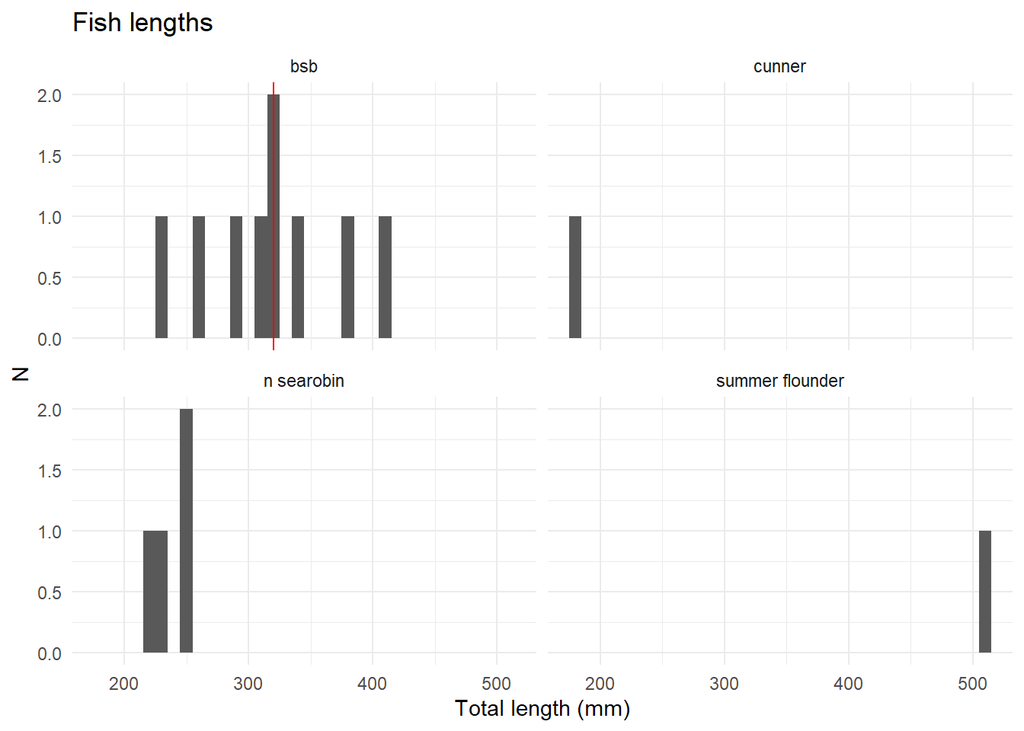

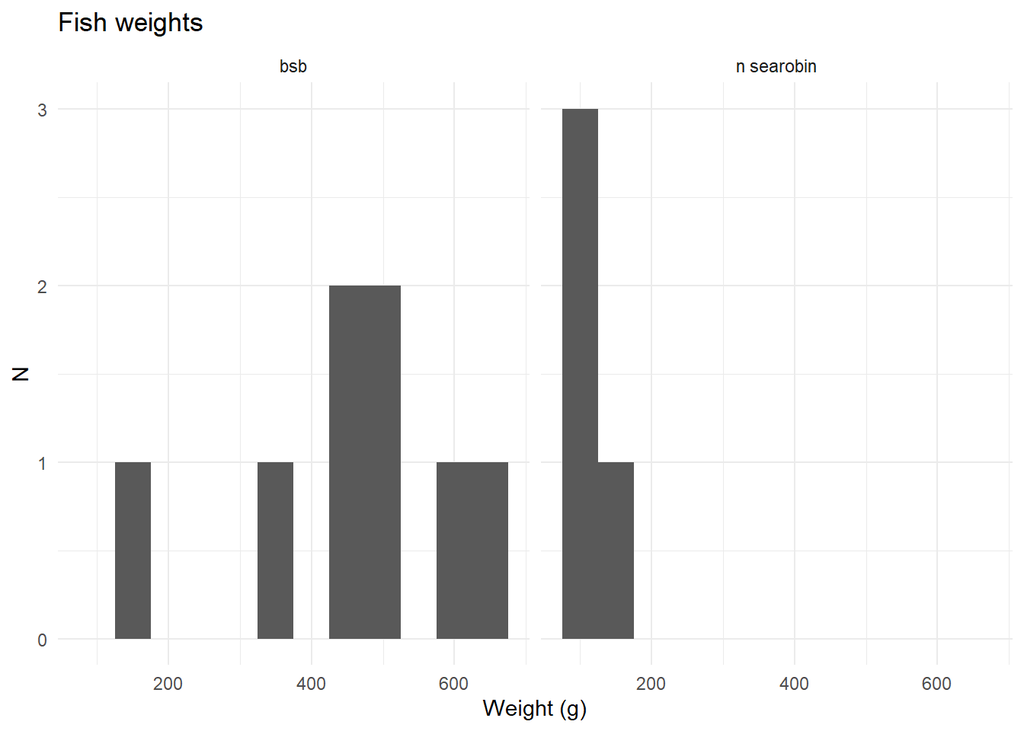

The effect of angler experience was great, with DW (Finchaser mate) and TS, the two most-experienced anglers, catching the most fish.

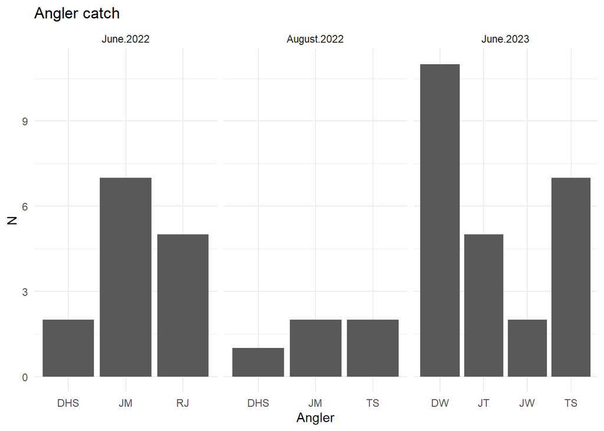

## Fish summary: Jig survey

Species catch, Jig

| species | n |
| --- | --- |
| 2022 - August - K07 |  |
| n searobin | 5 |
| 2022 - August - washingtonian |  |
| bsb | 1 |
| tautog | 1 |
| 2023 - June - K07 |  |
| n searobin | 4 |
| 2023 - June - M12 |  |
| n searobin | 2 |
| 2023 - June - twin wrecks |  |
| bsb | 1 |

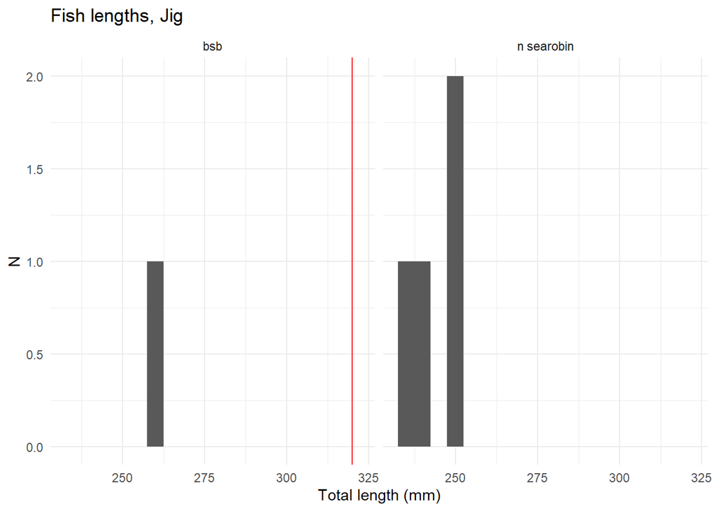

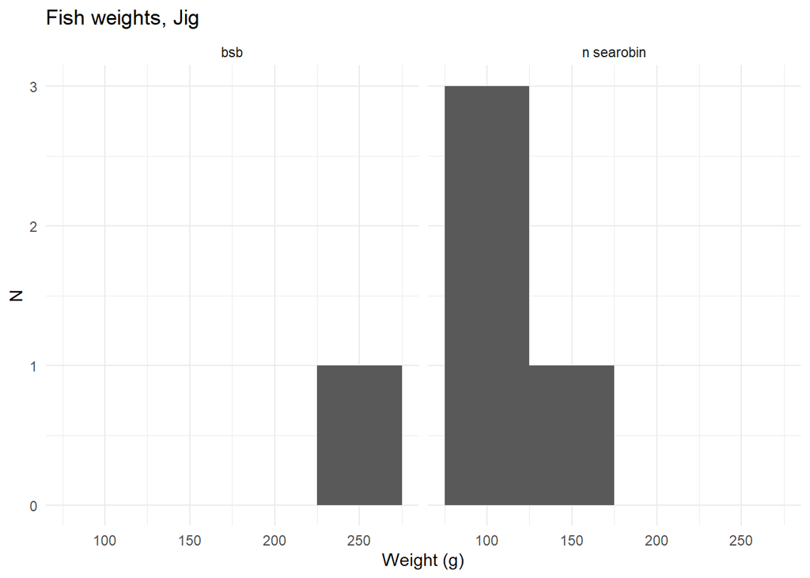

## Cruise map

[interactive chart not shown]